# Programming basics for Biostatistics 6099

Matplotlib

Zhiguang Huo (Caleb)

Thursday Nov 16th, 2023

# Outlines

- time series plot
- figure, axes and subplots
- color, linetype, markers
- scatter and line plot
- barplot, histogram, and density plot
- heatmap

# Get started

- Matplotlib: is a basic plotting library for the Python, its prefix “mat” indicates that its syntax is originated from Matlab.
  - package: matplotlib
  - sub package: pyplot
  - load the package:

```python
import matplotlib.pyplot as plt
```

# time series plot

A toy example

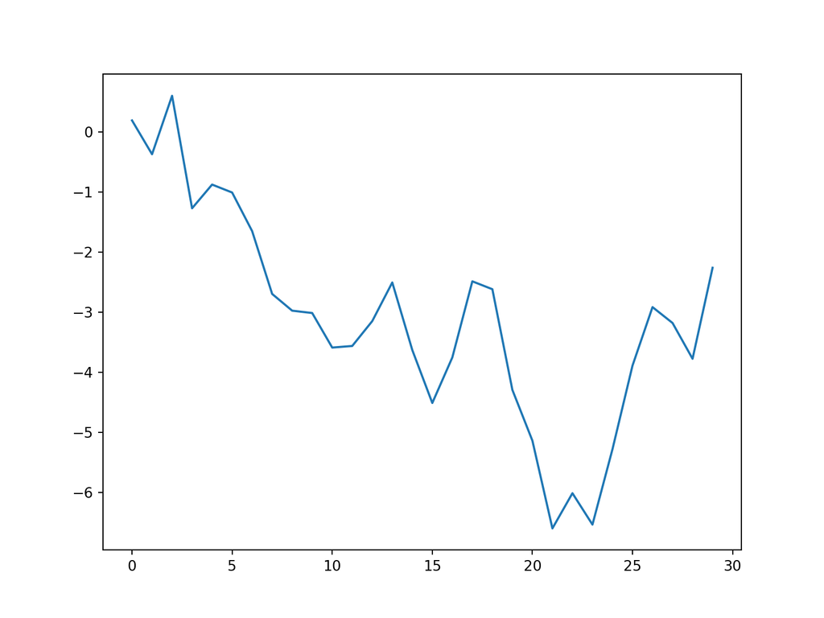

```python
rng = np.random.default_rng(32611)
data = rng.standard_normal(30)
data_cumsum = data.cumsum()
plt.plot(data_cumsum)
```

# Figure and axes

- The Figure object is the outermost container for a matplotlib graphic, which may contain multiple Axes objects.
- The Axes is an object containing attributes for individual plot, which can be created by
  - fig.add_subplot()

```
fig = plt.figure()
ax = fig.add_subplot()
ax.plot()
```

- plt.subplots()

```
fig, ax = plt.subplots()
ax.plot()
```

- plt.subplot(): no axes

```
plt.figure()
plt.subplot()
plt.plot()
```

# 1. use fig.add_subplot() to create Axes

Single figure

- add_subplot: (nrow, ncol, index)

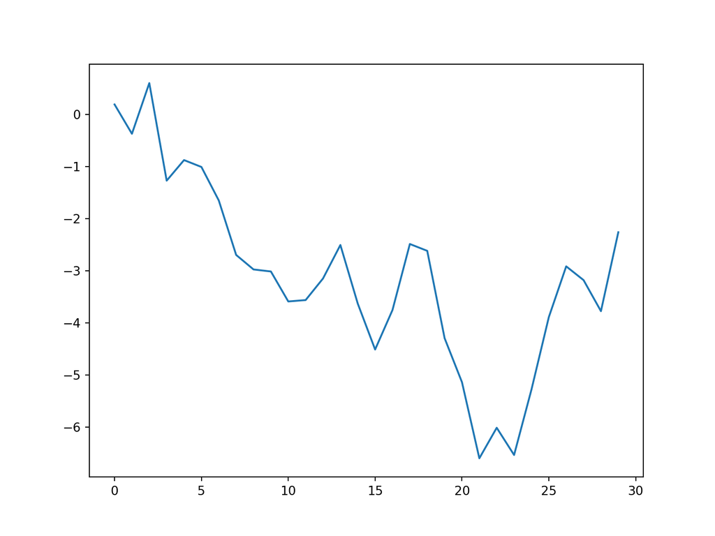

```python
fig = plt.figure()  # an empty figure with no Axes
ax = fig.add_subplot(1,1,1) # add one Axes
ax.plot(data_cumsum)
```

Multiple subfigures

- add_subplot: (nrow, ncol, index)
  - figsize = (width, height)

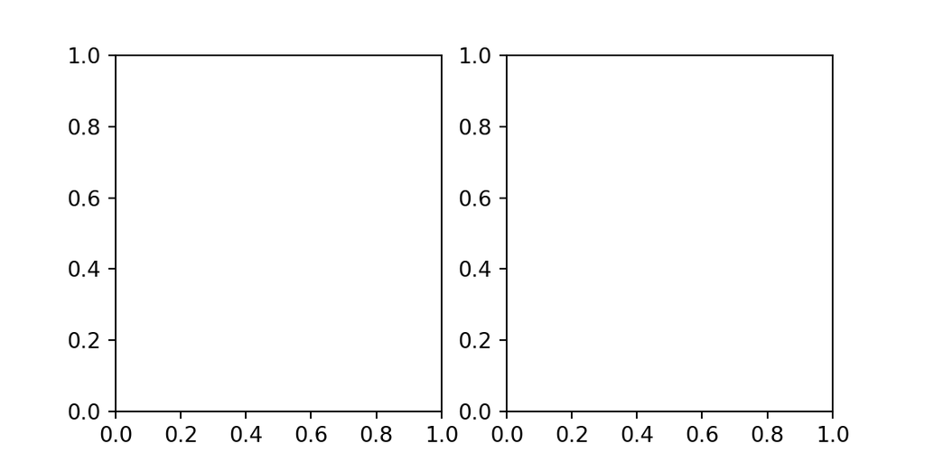

```python
fig = plt.figure(figsize=(6, 3))
ax1 = fig.add_subplot(1,2,1)
ax2 = fig.add_subplot(1,2,2)
plt.show()
```

# 2. use plt.subplots() to create Axes

Single figure

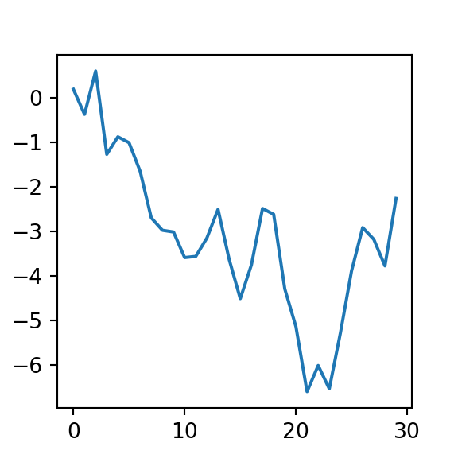

```python
fig, ax = plt.subplots(figsize=(3, 3))  # a figure with one Axes
ax
ax.plot(data_cumsum)
```

Multiple subfigures

- use subplots() to create multiple Axes

```python
fig, axs = plt.subplots(2, 2)  # a figure with a 2x2 grid of Axes
axs
```

```
## array([[<Axes: >, <Axes: >],
##        [<Axes: >, <Axes: >]], dtype=object)
```

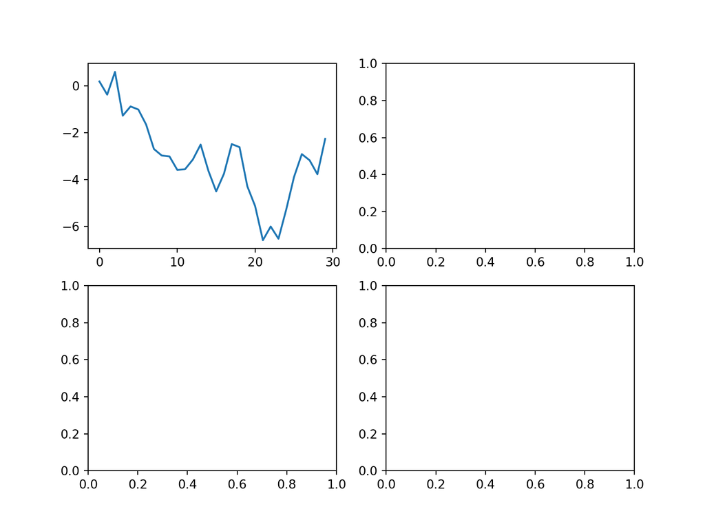

```python
axs[0,0].plot(data_cumsum)
```

# 3. use plt.subplot() to create Axes

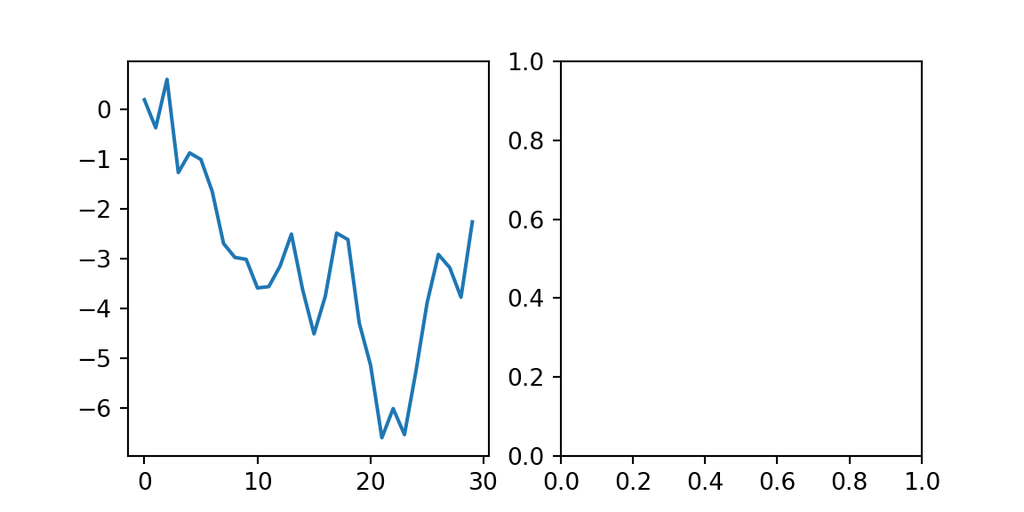

```python
plt.figure(figsize=(6, 3))
plt.subplot(1,2,1)
plt.plot(data_cumsum)
plt.subplot(122)
plt.show()
```

# colors

- basic color schemes:

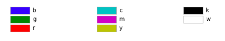

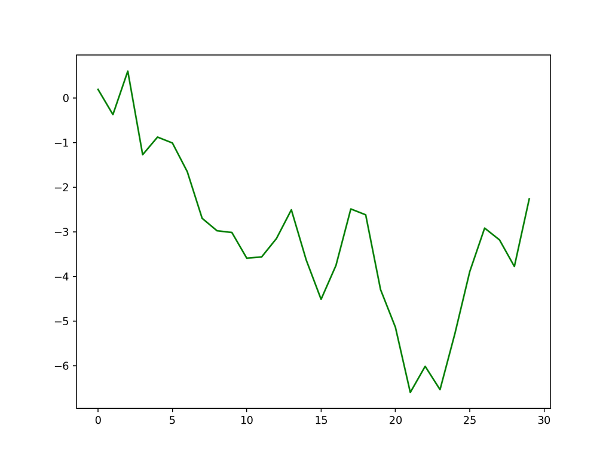

```python
plt.plot(data_cumsum, color = "g")
```

# colors

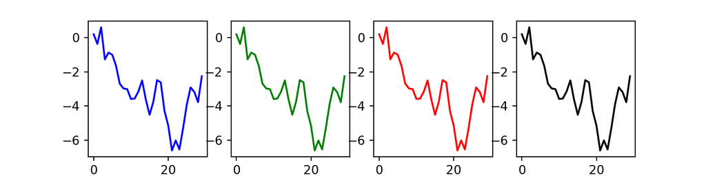

```python
fig = plt.figure(figsize=(8, 2))
ax1 = fig.add_subplot(1,4,1)
ax2 = fig.add_subplot(1,4,2)
ax3 = fig.add_subplot(1,4,3)
ax4 = fig.add_subplot(1,4,4)

ax1.plot(data_cumsum, color = "b")
ax2.plot(data_cumsum, color = "g")
ax3.plot(data_cumsum, color = "r")
ax4.plot(data_cumsum, color = "k")
```

# linestype

- solid or ‘-’
- dotted or ‘:’
- dashed or ‘–’
- dashdot or ‘-.’

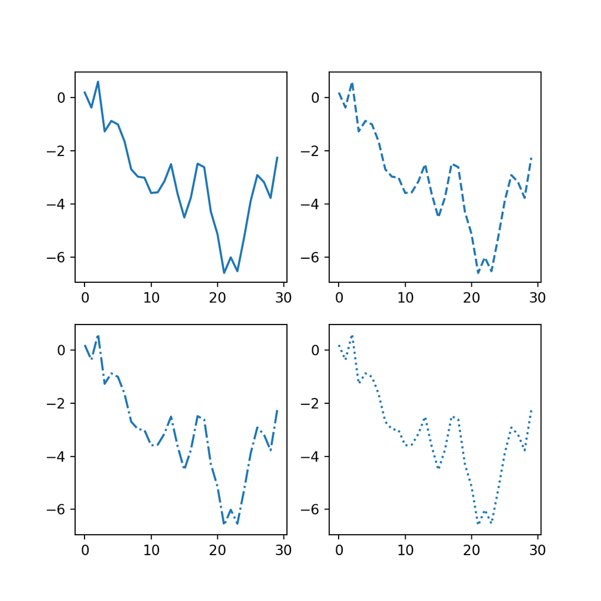

```python
plt.figure(figsize=(6, 6))
plt.subplot(221)
plt.plot(data_cumsum, linestyle = "-")
plt.subplot(222)
plt.plot(data_cumsum, linestyle = "--")
plt.subplot(223)
plt.plot(data_cumsum, linestyle = "-.")
plt.subplot(224)
plt.plot(data_cumsum, linestyle = ":")
plt.show()
```

# markers

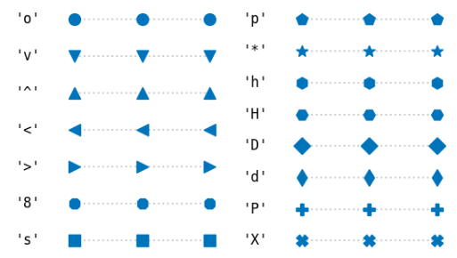

# markers

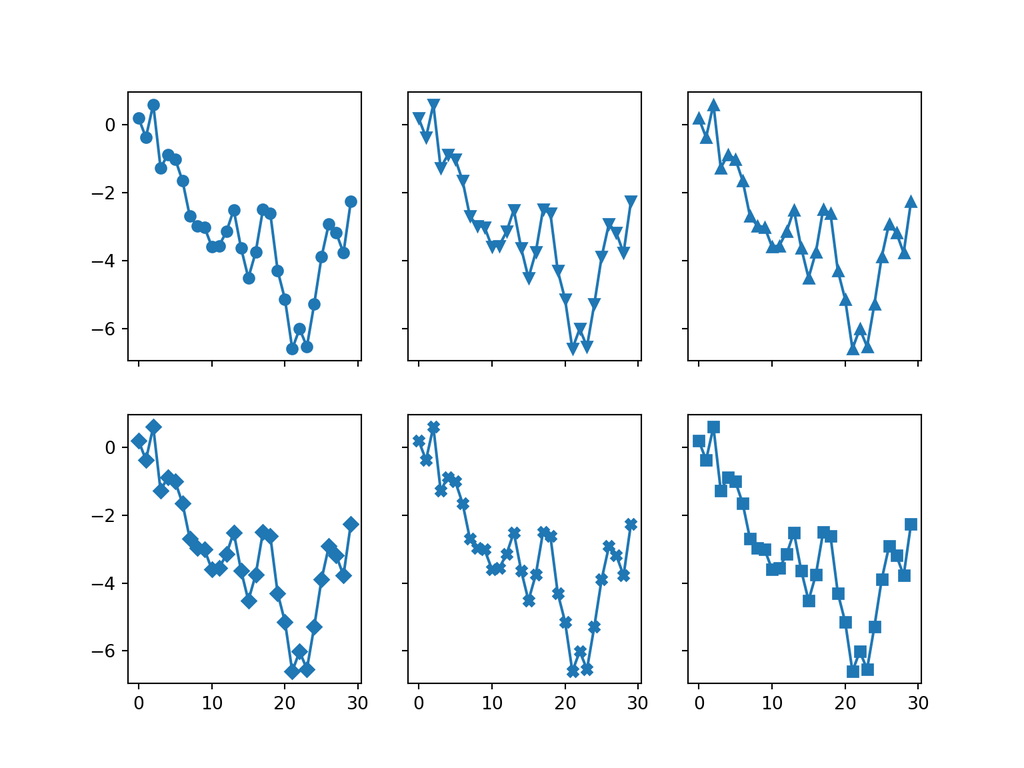

```python
fig, axes = plt.subplots(2,3,sharex=True, sharey=True)
axes[0,0].plot(data_cumsum, marker = "o")
axes[0,1].plot(data_cumsum, marker = "v")
axes[0,2].plot(data_cumsum, marker = "^")
axes[1,0].plot(data_cumsum, marker = "D")
axes[1,1].plot(data_cumsum, marker = "X")
axes[1,2].plot(data_cumsum, marker = "s")
plt.show()
```

# combinations of color, markers, and linestyle

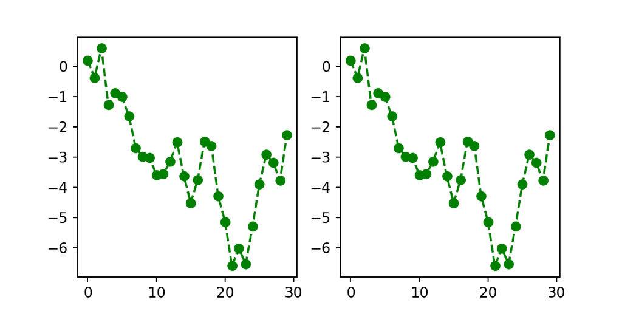

```python
plt.figure(figsize=(6, 3))
plt.subplot(121)
plt.plot(data_cumsum, linestyle = "--", color="g", marker="o")
plt.subplot(122)
plt.plot(data_cumsum,"go--") ## color, marker, linestyle
plt.show()
```

# ticks and labels

- create subplot and assign to ax
  - ax.set_xticks: set ticks for x axis
  - ax.set_xticklabels: set ticks labels for x axis
  - ax.set_xlabel: set labels for x axis
  - ax.set_title: set titles for the subplot

also works for y axis (set_yticks, set_xticklabels, etc)

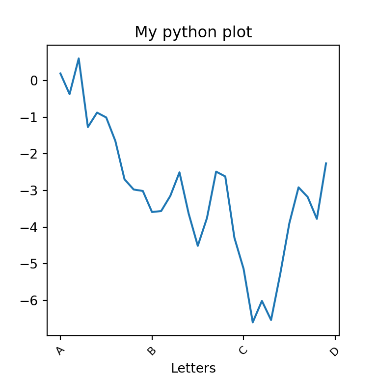

```python
fig = plt.figure(figsize=(4, 4))
ax = fig.add_subplot(1,1,1)
ax.plot(data_cumsum)
ticks = ax.set_xticks([0,10,20,30])
labels = ax.set_xticklabels(["A", "B", "C", "D"], rotation=45, fontsize = "small")
ax.set_xlabel("Letters")
ax.set_title("My python plot")
```

# legend

- add legend by label argument
- create legend by
  - ax.legend()
  - plt.legend()

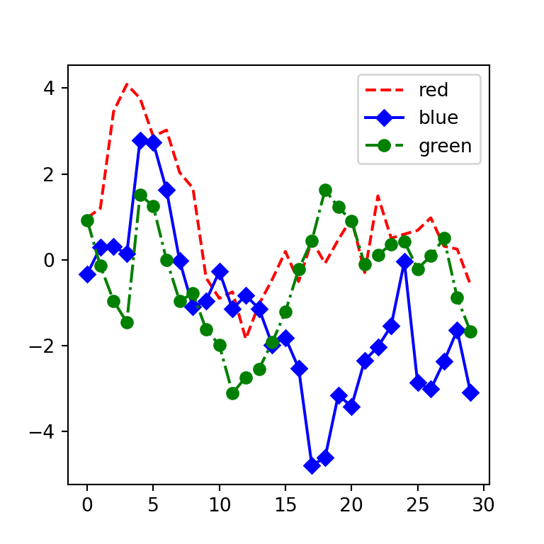

```python
fig = plt.figure(figsize=(4, 4))
ax = fig.add_subplot(1,1,1)
ax.plot(rng.standard_normal(30).cumsum(), "r--", label="red")
ax.plot(rng.standard_normal(30).cumsum(), "bD-", label="blue")
ax.plot(rng.standard_normal(30).cumsum(), "go-.", label="green")
ax.legend(loc="best")
plt.show()
```

# Summary of plt attributes

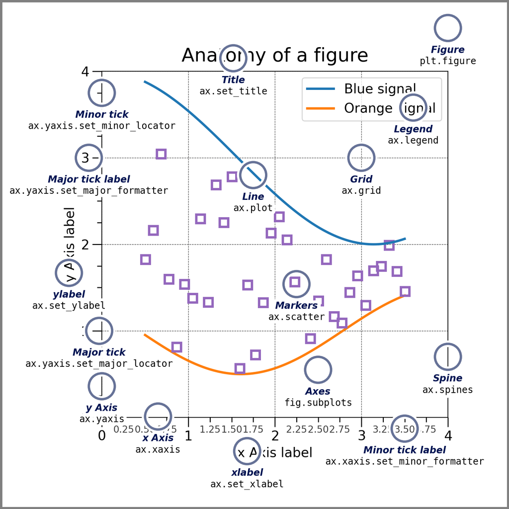

# Scatter plot

- prepare data as individual vectors
  - np.series
  - list

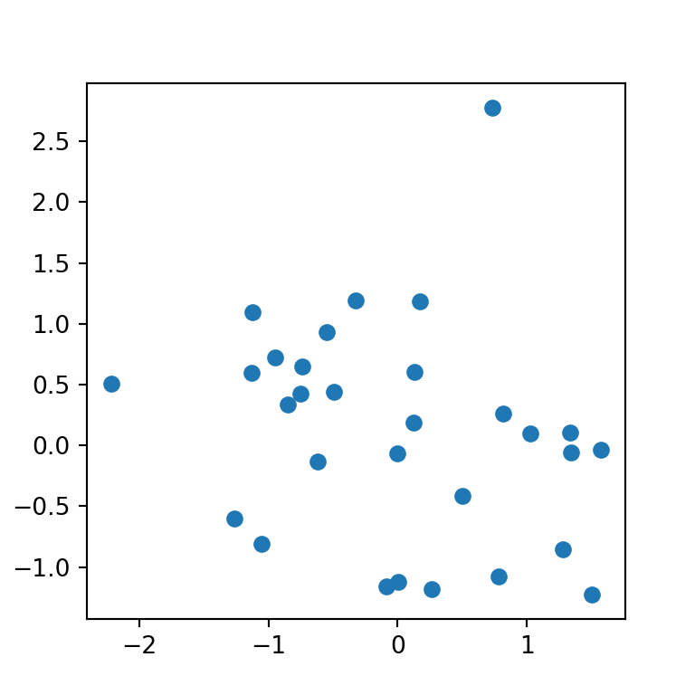

```python
rng = np.random.default_rng()
data1 = rng.standard_normal(30)
data2 = rng.standard_normal(30)

plt.figure(figsize=(4, 4))
plt.subplot()
plt.scatter(data1, data2)
```

# Scatter plot

- prepare data as pd.DataFrame

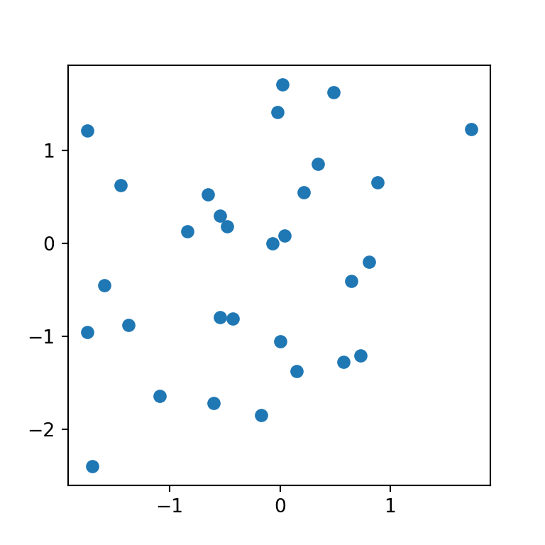

```python
fig = plt.figure(figsize=(4, 4))
ax = fig.add_subplot(1,1,1)

rng = np.random.default_rng()
data1 = rng.standard_normal(30)
data2 = rng.standard_normal(30)
df = pd.DataFrame({"A": data1, "B": data2})
ax.scatter("A", "B", data=df)
plt.show()
```

# Scatter plot

- use pd.DataFrame .plot methods

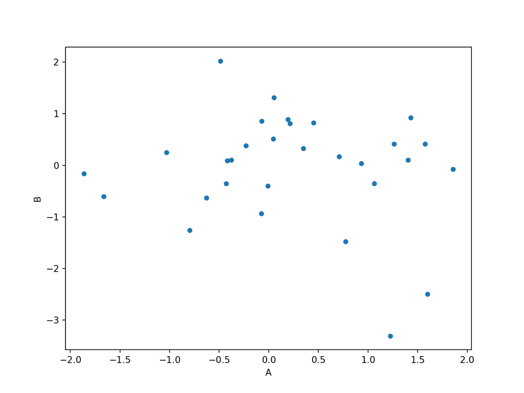

```python
rng = np.random.default_rng()
data1 = rng.standard_normal(30)
data2 = rng.standard_normal(30)
df = pd.DataFrame({"A": data1, "B": data2})
df.plot.scatter("A", "B")
```

- use pd.DataFrame .plot methods with axes
  - specify axes in the ax argument

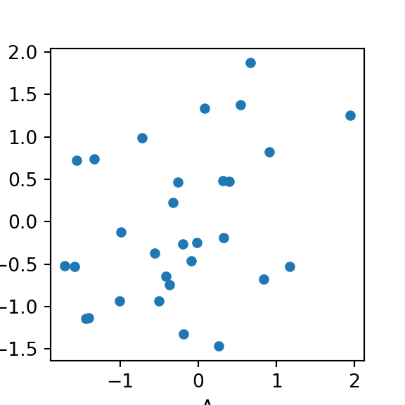

```python
fig, axes = plt.subplots(1,1,figsize=(3, 3))
rng = np.random.default_rng()
data1 = rng.standard_normal(30)
data2 = rng.standard_normal(30)
df = pd.DataFrame({"A": data1, "B": data2})
df.plot.scatter("A", "B", ax=axes)
```

# line plot

- prepare data as individual vectors
  - np.series
  - list

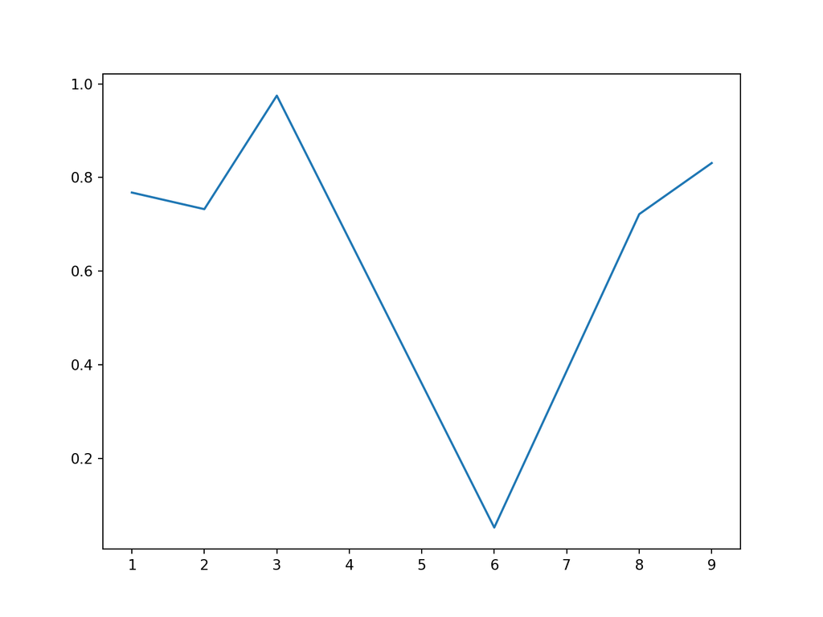

```python
a = np.array([1,2,3,6,8,9])
b = np.random.default_rng(32608).random(6)
plt.plot(a,b)
```

# line plot

- prepare data as pd.DataFrame

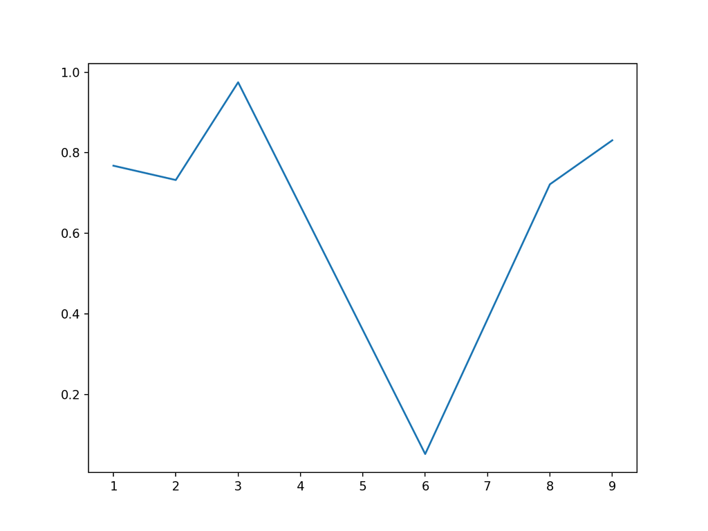

```python
a = np.array([1,2,3,6,8,9])
b = np.random.default_rng(32608).random(6)
df = pd.DataFrame({"A":a, "B":b})
plt.plot("A","B", data=df)
```

# line plot

- use pd.DataFrame .plot methods

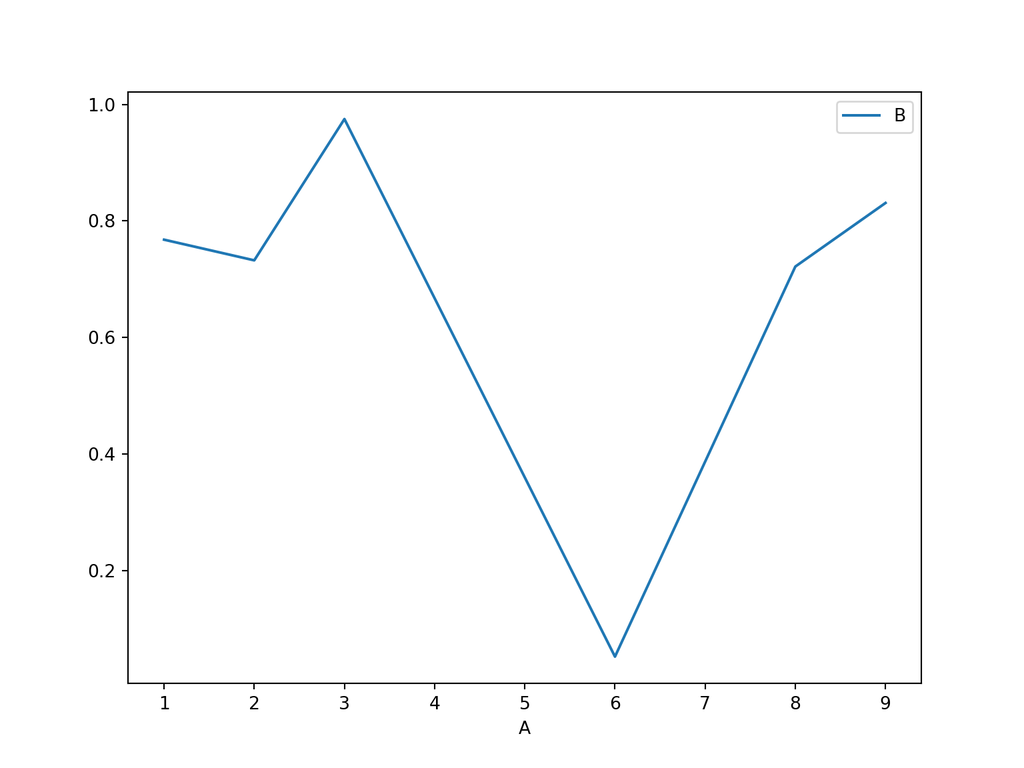

```python
a = np.array([1,2,3,6,8,9])
b = np.random.default_rng(32608).random(6)
df = pd.DataFrame({"A":a, "B":b})
df.plot.line("A","B")
```

- use pd.DataFrame .plot methods with axes
  - specify axes in the ax argument

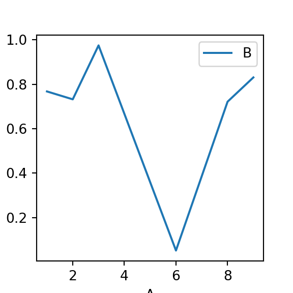

```python
fig, axes = plt.subplots(1,1,figsize=(3, 3))
a = np.array([1,2,3,6,8,9])
b = np.random.default_rng(32608).random(6)
df = pd.DataFrame({"A":a, "B":b})
df.plot.line("A","B", ax=axes)
```

# Categorical variable

- bar plot

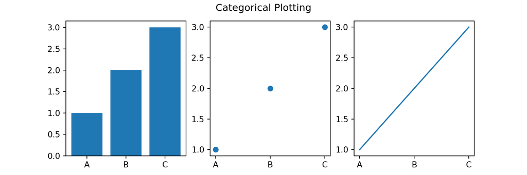

```python
df = pd.DataFrame({"names":['A', 'B', 'C'], "values":[1,2,3]})
plt.figure(figsize=(9, 3))
plt.subplot(131)
plt.bar("names", "values", data=df)
plt.subplot(132)
plt.scatter("names", "values", data=df)
plt.subplot(133)
plt.plot("names", "values", data=df)
plt.suptitle('Categorical Plotting')
plt.show()
```

# Bar plot

- use DataFrame plot methods
- horizontal bar plot

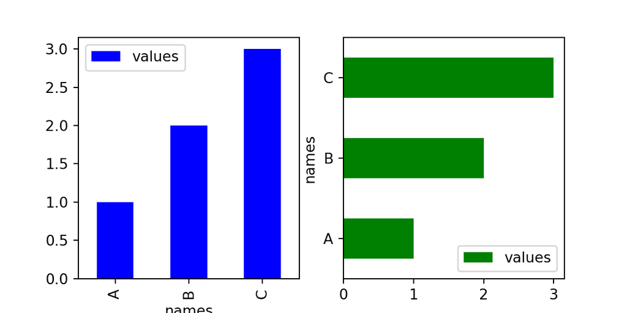

```python
df = pd.DataFrame({"names":['A', 'B', 'C'], "values":[1,2,3]})
fig, axes = plt.subplots(1,2,figsize=(6, 3))
df.plot.bar("names", "values", ax=axes[0], color="b")
df.plot.barh("names", "values", ax=axes[1], color="g")
```

# Bar plot with subgroups

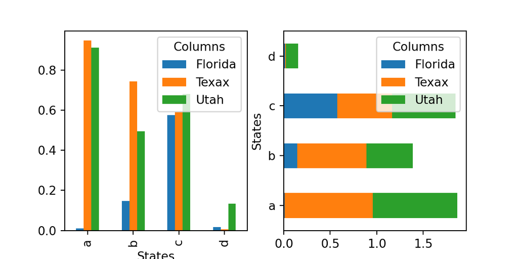

```python
pd1 = pd.DataFrame(np.random.rand(4,3), index = list("abcd"), columns = ["Florida", "Texax", "Utah"])
pd1.columns.name="Columns"
pd1.index.name="States"

fig = plt.figure(figsize=(6, 3))
ax = fig.add_subplot(1,2,1)
pd1.plot.bar(ax = ax)

bx = fig.add_subplot(1,2,2)
pd1.plot.barh(ax = bx, stacked=True)
plt.show()
```

# Histogram and density plot

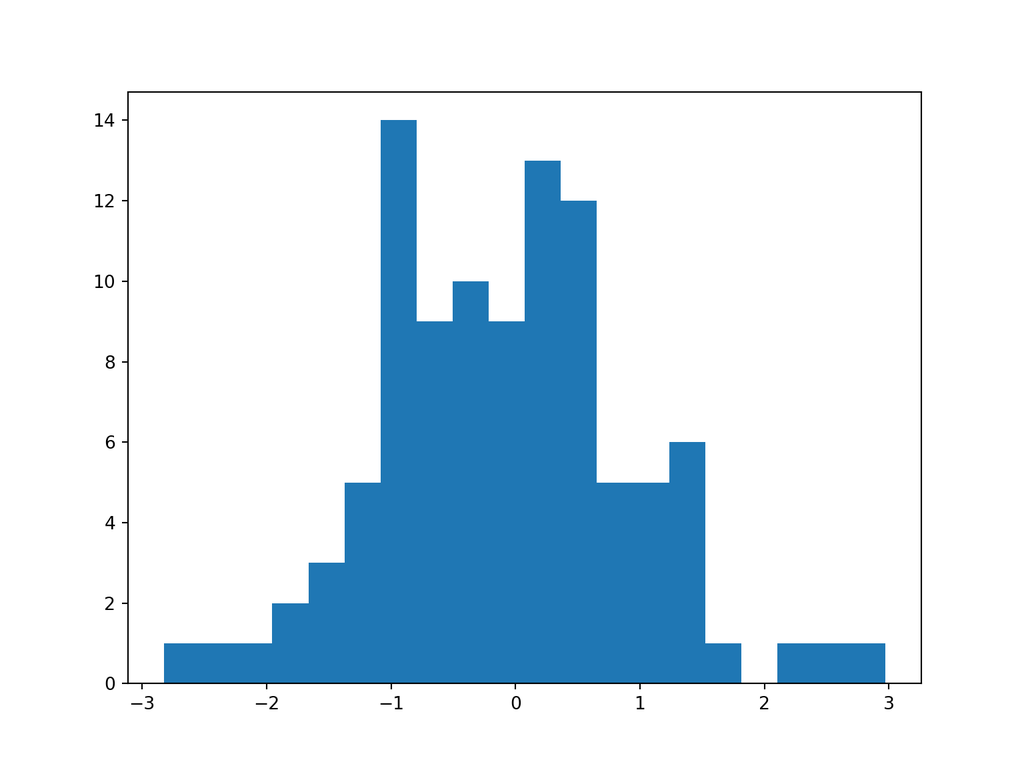

```python
rng = np.random.default_rng(32611)
data = rng.standard_normal(100)
plt.hist(data, bins=20)
plt.show()
```

# Histogram and density plot

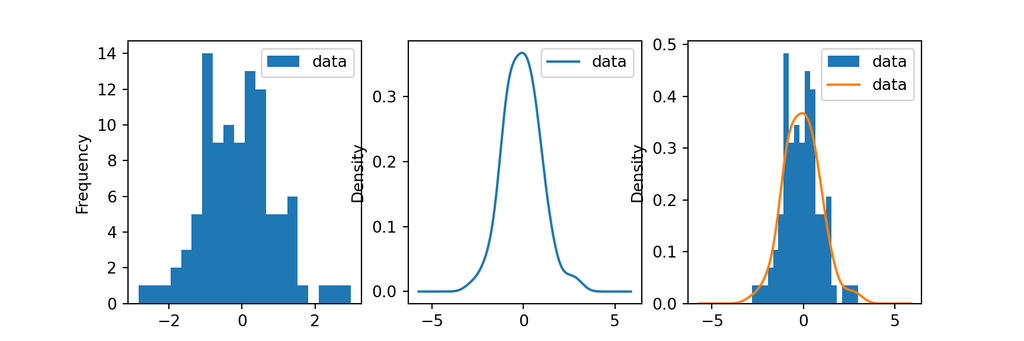

```python
data2 = pd.DataFrame({"data": data})
fig, axes = plt.subplots(1,3,figsize=(9, 3))
data2.plot.hist(bins=20, ax = axes[0])
data2.plot.density(ax = axes[1])
data2.plot.hist(bins=20,density=True, ax = axes[2])
data2.plot.density(ax = axes[2])
plt.show()
```

# heatmap

- plt.axes: Add an Axes to the current figure and make it the current Axes.
  - argument: a 4-tuple of floats rect = [left, bottom, width, height]

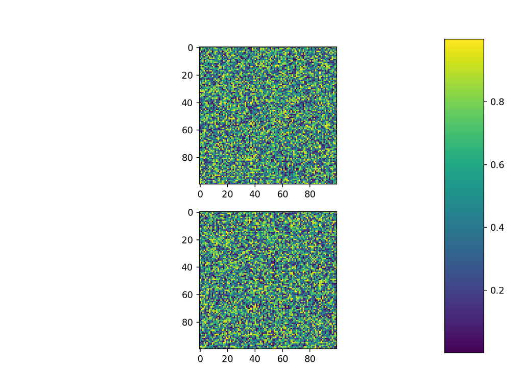

```python
np.random.seed(32608)
plt.subplot(211)
plt.imshow(np.random.random((100, 100)))
plt.subplot(212)
plt.imshow(np.random.random((100, 100)))
cax = plt.axes([0.85, 0.1, 0.075, 0.8])
plt.colorbar(cax=cax)
plt.show()
```

# Reference

- https://wesmckinney.com/book/plotting-and-visualization.html
- https://matplotlib.org/stable/tutorials/introductory